# Homework #3

Chase Weida; Github: cweida

2/12/2020

### 1

How many parties did the waiter serve? Store the number in numParty and print.

```r
length(tips$total_bill)
```

```
## [1] 244
```

```r
numParty <- length(tips$total_bill)
numParty
```

```
## [1] 244
```

### 2

What are the types of variables in the data frame tips? Include the code and also explain verbally.

```r
str(tips)
```

```
## 'data.frame':    244 obs. of  7 variables:
##  $ total_bill: num  17 10.3 21 23.7 24.6 ...
##  $ tip       : num  1.01 1.66 3.5 3.31 3.61 4.71 2 3.12 1.96 3.23 ...
##  $ sex       : Factor w/ 2 levels "Female","Male": 1 2 2 2 1 2 2 2 2 2 ...
##  $ smoker    : Factor w/ 2 levels "No","Yes": 1 1 1 1 1 1 1 1 1 1 ...
##  $ day       : Factor w/ 4 levels "Fri","Sat","Sun",..: 3 3 3 3 3 3 3 3 3 3 ...
##  $ time      : Factor w/ 2 levels "Dinner","Lunch": 1 1 1 1 1 1 1 1 1 1 ...
##  $ size      : int  2 3 3 2 4 4 2 4 2 2 ...
```

As one can see, the data type for each column of the data frame are:

total_bill= num  
tip = num  
sex = Factor  
smoker = Factor  
day = Factor  
time = Factor  
size = int

### 3

Create a vector named day containing the day of visits in tips. The factor levels should be ordered from Thursday to Sunday. Print the variable.

```r
day <- tips$day[order(factor(tips$day,levels = c('Thur', 'Fri', "Sat", "Sun")))]
day
```

```
##   [1] Thur Thur Thur Thur Thur Thur Thur Thur Thur Thur Thur Thur Thur Thur Thur
##  [16] Thur Thur Thur Thur Thur Thur Thur Thur Thur Thur Thur Thur Thur Thur Thur
##  [31] Thur Thur Thur Thur Thur Thur Thur Thur Thur Thur Thur Thur Thur Thur Thur
##  [46] Thur Thur Thur Thur Thur Thur Thur Thur Thur Thur Thur Thur Thur Thur Thur
##  [61] Thur Thur Fri  Fri  Fri  Fri  Fri  Fri  Fri  Fri  Fri  Fri  Fri  Fri  Fri
##  [76] Fri  Fri  Fri  Fri  Fri  Fri  Sat  Sat  Sat  Sat  Sat  Sat  Sat  Sat  Sat
##  [91] Sat  Sat  Sat  Sat  Sat  Sat  Sat  Sat  Sat  Sat  Sat  Sat  Sat  Sat  Sat
## [106] Sat  Sat  Sat  Sat  Sat  Sat  Sat  Sat  Sat  Sat  Sat  Sat  Sat  Sat  Sat
## [121] Sat  Sat  Sat  Sat  Sat  Sat  Sat  Sat  Sat  Sat  Sat  Sat  Sat  Sat  Sat
## [136] Sat  Sat  Sat  Sat  Sat  Sat  Sat  Sat  Sat  Sat  Sat  Sat  Sat  Sat  Sat
## [151] Sat  Sat  Sat  Sat  Sat  Sat  Sat  Sat  Sat  Sat  Sat  Sat  Sat  Sat  Sat
## [166] Sat  Sat  Sat  Sun  Sun  Sun  Sun  Sun  Sun  Sun  Sun  Sun  Sun  Sun  Sun
## [181] Sun  Sun  Sun  Sun  Sun  Sun  Sun  Sun  Sun  Sun  Sun  Sun  Sun  Sun  Sun
## [196] Sun  Sun  Sun  Sun  Sun  Sun  Sun  Sun  Sun  Sun  Sun  Sun  Sun  Sun  Sun
## [211] Sun  Sun  Sun  Sun  Sun  Sun  Sun  Sun  Sun  Sun  Sun  Sun  Sun  Sun  Sun
## [226] Sun  Sun  Sun  Sun  Sun  Sun  Sun  Sun  Sun  Sun  Sun  Sun  Sun  Sun  Sun
## [241] Sun  Sun  Sun  Sun
## Levels: Fri Sat Sun Thur
```

### 4

Create a data frame named female5 containing the meal paid by a female payer in a party with size greater than or equal to 5. Print the data frame.

```r
female5 <- tips[tips$sex == "Female" & tips$size >= 5,]
female5
```

```
##     total_bill  tip    sex smoker  day   time size
## 126      29.80 4.20 Female     No Thur  Lunch    6
## 144      27.05 5.00 Female     No Thur  Lunch    6
## 156      29.85 5.14 Female     No  Sun Dinner    5
```

### 5

How does the tipping amount (tip) depend on the overall bill (total_bill)? Use the ggplot2 package to make a chart. Describe the relationship in words.

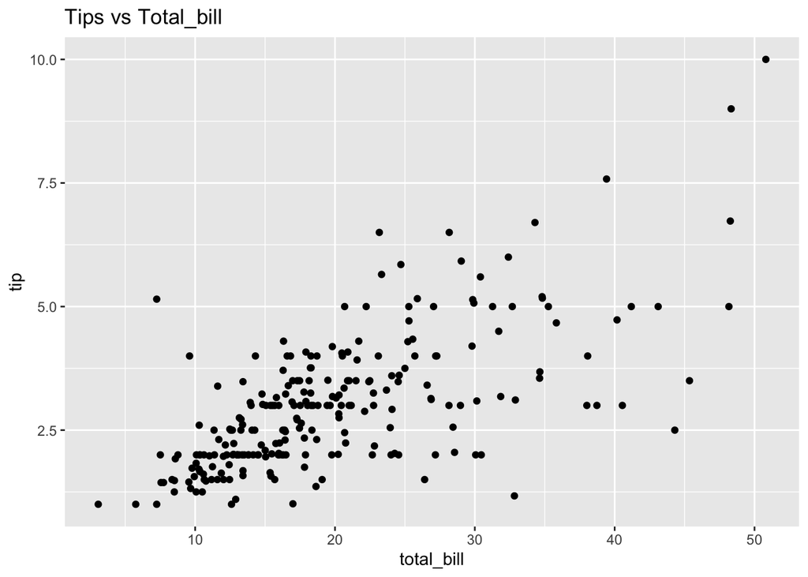

```r
ggplot(tips,aes(x = total_bill, y = tip)) + geom_point() + ggtitle("Tips vs Total_bill")
```

Upon visual inspection, one can see a linear relationship between the size of the total bill and tip size. As the bill increases, the tip grows slowly.

### 6

Describe at least two types of anomalies in the previous plot. What do they mean?

One can see that there is a point which falls below the 10 dollar total bill cost and above the 5 dollar tip point. This means that someone tipped well above average on that particular bill, in excess of 50%. Additionally, one can see a data point which falls above the 30 dolla total bill cost and well below the 2.5 dollar tip level. This means that they tipped well below the average. This tip was probably below 5%.

### 7

Introduce a variable tiprate into the data set which stands for the rate of tips. What is the average rate for tips? Explain verbally.

```r
tipRate <- tips$tip/tips$total_bill
tips$tipRate <- tipRate
meanTip <- mean(tips$tipRate)
meanTip
```

```
## [1] 0.1608026
```

As demonstrated above, the mean value of the tipRate column is approximately .16 or 16%. Thus, the average party for this particular waiter gave about 16% of the bill as a tip. This is 1% above the customary 15% tip.

### 8

Make a boxplot of the tip rate by time. The x-axis should be ordered by lunch and then dinner. Use ggplot2 to make a chart. Verbally explain the chart.

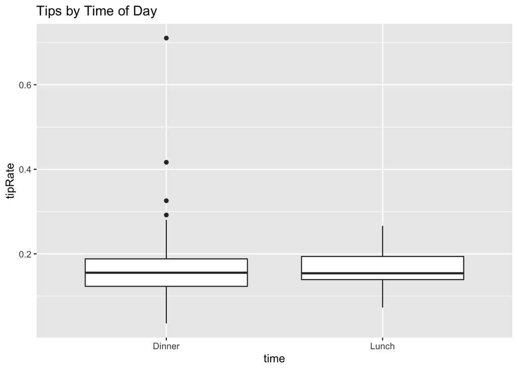

```r
tipByTime <- tips[order(factor(tips$time,levels = c('Lunch','Dinner'))),]
ggplot(tipByTime, aes(x = time, y = tipRate)) + geom_boxplot() + ggtitle("Tips by Time of Day")
```